# Analysis of Human Activity Recognition

## I Synopsis

In this report, I create a random forest predictive model to predict classe variable in Human Activity Recognition data, and the prediction accuracy is very high. The dataset is first used in Ugulino, W.; Cardador, D.; Vega, K.; Velloso, E.; Milidiu, R.; Fuks, H. Wearable Computing: Accelerometers’ Data Classification of Body Postures and Movements. Proceedings of 21st Brazilian Symposium on Artificial Intelligence.  
Read more: http://groupware.les.inf.puc-rio.br/har#sbia_paper_section#ixzz3SVQSyTxz

## II Data Processing

### II-1 Load data

First, load necessary libraries.

```r
library(caret)
library(randomForest)
```

Suppose now I have downloaded corresponding train/test datasets, and the current directory has the datasets. I can directly load data into R console. Notice that according to the codebook, the NAs can be “NA”, “#DIV/0!” and “”.

```r
train_data <- read.csv("pml-training.csv", na.strings=c("NA","#DIV/0!", ""))
test_data <- read.csv("pml-testing.csv", na.strings=c("NA","#DIV/0!", ""))
```

I check the train data, and find that there are 160 variables.

```r
str(train_data)
```

[output not shown]

### II-2 Process data

```r
train <- subset(train_data, select = c(roll_belt: classe))
train <- train[, apply(train, 2, function(x) !any(is.na(x)))]

inTrain <- createDataPartition(y = train$classe, p = 0.7, list = FALSE)
training <- train[inTrain, ]
testing <- train[-inTrain, ]
```

At last, the variables used in training/testing dataset are illusrated below.

```r
names(training)
```

```
##  [1] "roll_belt"            "pitch_belt"           "yaw_belt"
##  [4] "total_accel_belt"     "gyros_belt_x"         "gyros_belt_y"
##  [7] "gyros_belt_z"         "accel_belt_x"         "accel_belt_y"
## [10] "accel_belt_z"         "magnet_belt_x"        "magnet_belt_y"
## [13] "magnet_belt_z"        "roll_arm"             "pitch_arm"
## [16] "yaw_arm"              "total_accel_arm"      "gyros_arm_x"
## [19] "gyros_arm_y"          "gyros_arm_z"          "accel_arm_x"
## [22] "accel_arm_y"          "accel_arm_z"          "magnet_arm_x"
## [25] "magnet_arm_y"         "magnet_arm_z"         "roll_dumbbell"
## [28] "pitch_dumbbell"       "yaw_dumbbell"         "total_accel_dumbbell"
## [31] "gyros_dumbbell_x"     "gyros_dumbbell_y"     "gyros_dumbbell_z"
## [34] "accel_dumbbell_x"     "accel_dumbbell_y"     "accel_dumbbell_z"
## [37] "magnet_dumbbell_x"    "magnet_dumbbell_y"    "magnet_dumbbell_z"
## [40] "roll_forearm"         "pitch_forearm"        "yaw_forearm"
## [43] "total_accel_forearm"  "gyros_forearm_x"      "gyros_forearm_y"
## [46] "gyros_forearm_z"      "accel_forearm_x"      "accel_forearm_y"
## [49] "accel_forearm_z"      "magnet_forearm_x"     "magnet_forearm_y"
## [52] "magnet_forearm_z"     "classe"
```

### II-3 Construct predictive model

I perfer to leverage random forest to predict classe viarable. The procedure is demonstrated below.

```r
modelFit <- randomForest(classe ~ ., data = training)
modelFit
```

```
##
## Call:
##  randomForest(formula = classe ~ ., data = training)
##                Type of random forest: classification
##                      Number of trees: 500
## No. of variables tried at each split: 7
##
##         OOB estimate of  error rate: 0.46%
## Confusion matrix:
##      A    B    C    D    E class.error
## A 3902    4    0    0    0 0.001024066
## B   14 2641    3    0    0 0.006395786
## C    0   12 2382    2    0 0.005843072
## D    0    0   19 2232    1 0.008880995
## E    0    0    3    5 2517 0.003168317
```

The model’s OOB estimate of error rate is just 0.46%. So it seems that the model is very accurate. Now I need to implement cross validation to explore the model further.

```r
cross_val <- predict(modelFit, testing)
confusionMatrix(testing$classe, cross_val)
```

```
## Confusion Matrix and Statistics
##
##           Reference
## Prediction    A    B    C    D    E
##          A 1674    0    0    0    0
##          B    0 1139    0    0    0
##          C    0    1 1025    0    0
##          D    0    0    4  960    0
##          E    0    0    0    0 1082
##
## Overall Statistics
##
##                Accuracy : 0.9992
##                  95% CI : (0.998, 0.9997)
##     No Information Rate : 0.2845
##     P-Value [Acc > NIR] : < 2.2e-16
##
##                   Kappa : 0.9989
##  Mcnemar's Test P-Value : NA
##
## Statistics by Class:
##
##                      Class: A Class: B Class: C Class: D Class: E
## Sensitivity            1.0000   0.9991   0.9961   1.0000   1.0000
## Specificity            1.0000   1.0000   0.9998   0.9992   1.0000
## Pos Pred Value         1.0000   1.0000   0.9990   0.9959   1.0000
## Neg Pred Value         1.0000   0.9998   0.9992   1.0000   1.0000
## Prevalence             0.2845   0.1937   0.1749   0.1631   0.1839
## Detection Rate         0.2845   0.1935   0.1742   0.1631   0.1839
## Detection Prevalence   0.2845   0.1935   0.1743   0.1638   0.1839
## Balanced Accuracy      1.0000   0.9996   0.9980   0.9996   1.0000
```

For the results above, I can observe that the accuracy is very high (more than 99%), and there are few prediction errors with this random forest model. A graph is shown below to demonstrate that.

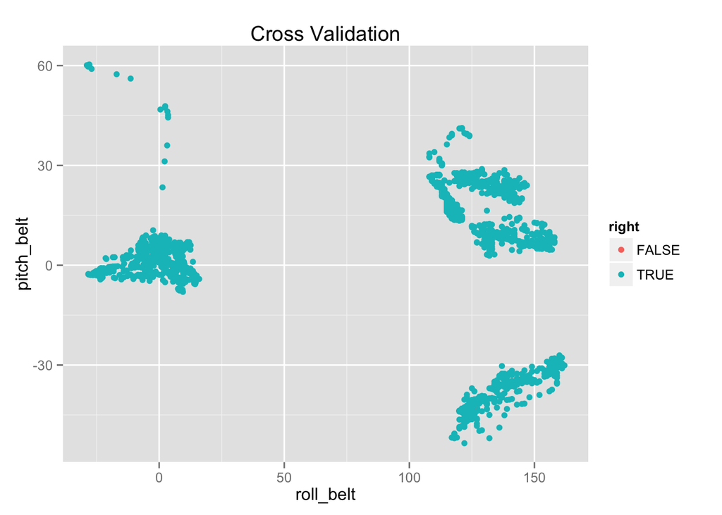

```r
testing$right <- cross_val==testing$classe
qplot(roll_belt, pitch_belt, colour=right, data=testing, main="Cross Validation")
```

### II-4 Predict test dataset

Now, with the random forest predictive model, I exploit it to predict classe variable in the test dataset. First, I implement same processing as training dataset.

```r
test <- subset(test_data, select = c(roll_belt: problem_id))
test <- test[, apply(test, 2, function(x) !any(is.na(x)))]
test$classe <- c("A", "B", "C", "D", "E")
test$classe <- as.factor(test$classe)
test$problem_id <- NULL
```

After the preprocessing, I use the previous predictive model to predict test dataset.

```r
predict(modelFit, test)
```

```
##  1  2  3  4  5  6  7  8  9 10 11 12 13 14 15 16 17 18 19 20
##  B  A  B  A  A  E  D  B  A  A  B  C  B  A  E  E  A  B  B  B
## Levels: A B C D E
```

## III Submit Results

Now, I need to submit the results onto the Coursera. The functions needed are shown below.

```r
submit <- function() {
    answers <- c("B", "A", "B", "A", "A", "E", "D", "B", "A", "A",
                 "B", "C", "B", "A", "E", "E", "A", "B", "B", "B")
    pml_write_files(answers)
}

pml_write_files <- function(x){
    n = length(x)
    for(i in 1:n){
        filename = paste0("problem_id_",i,".txt")
        write.table(x[i],file=filename,quote=FALSE,row.names=FALSE,col.names=FALSE)
    }
}
```